# R Notebook

I would like to recognize geeks for geeks, w3schools, and copilot as they were intrumental sources that supported my understanding of this data.

First I will attach the library packages I will need for my analysis

```r
library(readr)
library(dplyr)
library(ggplot2)

summary(car_df)
```

[output not shown]

I will be working on a USA car dataset.

```r
#reading my car dataset
file_path <- "USA_cars_datasets.csv"
cars_df <- read_csv(file_path)
View(cars_df)
```

```r
#subset to create new df without unnamed column
#cars_df <- subset(cars_df, select = -c('Unnamed: 0'))
cars_df_new <- cars_df[, -1]

View(cars_df_new)
```

DESCRIPTIVE ANALYSIS

3. What is the structure of my data

```r
print(str(cars_df_new))
```

```
tibble [2,499 × 12] (S3: tbl_df/tbl/data.frame)
 $ price       : num [1:2499] 6300 2899 5350 25000 27700 ...
 $ brand       : chr [1:2499] "toyota" "ford" "dodge" "ford" ...
 $ model       : chr [1:2499] "cruiser" "se" "mpv" "door" ...
 $ year        : num [1:2499] 2008 2011 2018 2014 2018 ...
 $ title_status: chr [1:2499] "clean vehicle" "clean vehicle" "clean vehicle" "clean vehicle" ...
 $ mileage     : num [1:2499] 274117 190552 39590 64146 6654 ...
 $ color       : chr [1:2499] "black" "silver" "silver" "blue" ...
 $ vin         : chr [1:2499] "jtezu11f88k007763" "2fmdk3gc4bbb02217" "3c4pdcgg5jt346413" "1ftfw1et4efc23745" ...
 $ lot         : num [1:2499] 1.59e+08 1.67e+08 1.68e+08 1.68e+08 1.68e+08 ...
 $ state       : chr [1:2499] "new jersey" "tennessee" "georgia" "virginia" ...
 $ country     : chr [1:2499] "usa" "usa" "usa" "usa" ...
 $ condition   : chr [1:2499] "10 days left" "6 days left" "2 days left" "22 hours left" ...
NULL
```

Here I see that my data has 2,499 rows and 12 columns. I can also see that the columns are price,brand, model, year, title_status, mileage, color, vin, lot, state, country, condition.

4. Let’s view a summary statistics of my data(looking at all numeric columns)

```r
summary(select_if(cars_df_new, is.numeric))
```

```
     price            year         mileage             lot
 Min.   :    0   Min.   :1973   Min.   :      0   Min.   :159348797
 1st Qu.:10200   1st Qu.:2016   1st Qu.:  21467   1st Qu.:167625331
 Median :16900   Median :2018   Median :  35365   Median :167745058
 Mean   :18768   Mean   :2017   Mean   :  52299   Mean   :167691389
 3rd Qu.:25556   3rd Qu.:2019   3rd Qu.:  63473   3rd Qu.:167779772
 Max.   :84900   Max.   :2020   Max.   :1017936   Max.   :167805500
```

```r
lapply(select_if(cars_df_new, is.factor), table)
```

```
named list()
```

I see that my cars_df_new has a color column. I would like to dig into this 6. Are there certain colors that are more popular for cars?

```r
# using ggplot 2
#create color table..
#print the color frequency
#create a bar plot of color frequencies
car_color_freq <- table(cars_df_new$color)

print(car_color_freq)
```

```
                                  beige        billet silver metallic clearcoat
                                      5                                       3
                                  black                         black clearcoat
                                    516                                       2
                                   blue                  bright white clearcoat
                                    151                                       2
                                  brown                                burgundy
                                     15                                       1
                            cayenne red                                charcoal
                                      2                                      18
                                 color:                      competition orange
                                      5                                       1
                              dark blue                           glacier white
                                      1                                       1
                                   gold                                    gray
                                     19                                     395
                                  green                                   guard
                                     24                                       1
                           ingot silver                   ingot silver metallic
                                      1                                       4
                    jazz blue pearlcoat                      kona blue metallic
                                      1                                       1
                             light blue                          lightning blue
                                      1                                       1
                      magnetic metallic                                  maroon
                                      6                                       1
                        morningsky blue                                no_color
                                      1                                      61
                              off-white                                  orange
                                      2                                      20
                           oxford white                             pearl white
                                      4                                       1
                          phantom black                                  purple
                                      1                                       1
                                    red royal crimson metallic tinted clearcoat
                                    192                                       1
                               ruby red      ruby red metallic tinted clearcoat
                                      1                                       2
                           shadow black                                  silver
                                      5                                     300
                            super black                                     tan
                                      3                                       1
                           toreador red                  triple yellow tri-coat
                                      1                                       3
                              turquoise                   tuxedo black metallic
                                      1                                       2
                                  white        white platinum tri-coat metallic
                                    707                                       2
                                 yellow
                                      9
```

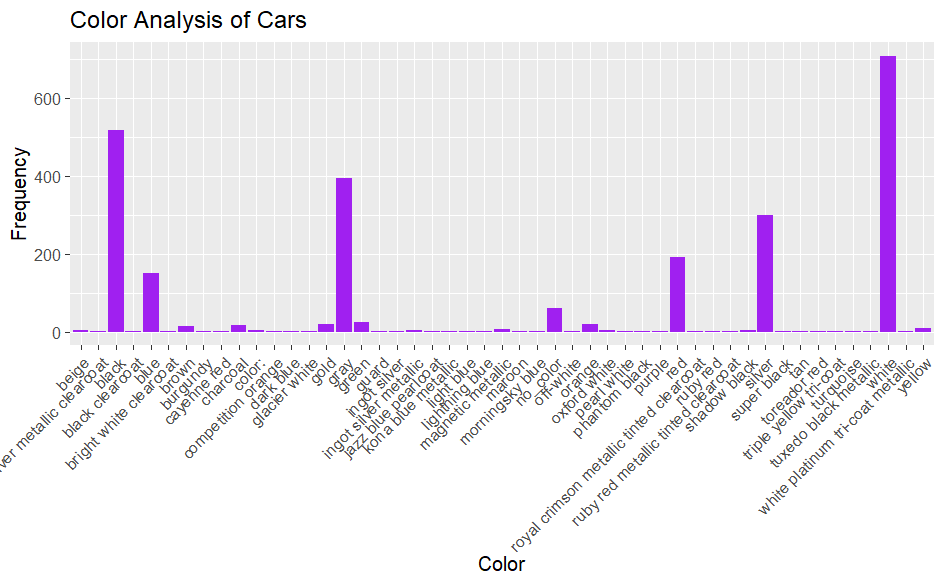

```r
#using car_color_freq
#create a bar plot of colors
color_var <- ggplot(data = as.data.frame(car_color_freq), aes(x = Var1, y = Freq)) +
  geom_bar(stat = "identity", fill = "purple") +
  theme(axis.text.x = element_text(angle = 45, hjust = 1)) +
  labs(x = "Color", y = "Frequency", title = "Color Analysis of Cars")

color_var
ggsave("color_var.png", plot = color_var, width = 6, height = 4)
```

The most frequent colors for cars are white, black, and silver/gray, as shown by the tallest bars on the graph.

Perhaps, there colors might be more popular for cars, given their higher frequency in the dataset.

7. Which car brands are the most common in the US?

```r
#count the freq of each brand in the 'brand' column
#sort in descending order to find the most comm. brands
car_brand <- table(cars_df_new$brand)

sorted_car_brands <- sort(car_brand, decreasing = TRUE)

print(sorted_car_brands)
```

```
           ford           dodge          nissan       chevrolet             gmc
           1235             432             312             297              42
           jeep        chrysler             bmw         hyundai           buick
             30              18              17              15              13
            kia           honda        infiniti        cadillac   mercedes-benz
             13              12              12              10              10
      heartland            audi            land       peterbilt           acura
              5               4               4               4               3
          lexus         lincoln           mazda harley-davidson          jaguar
              2               2               2               1               1
       maserati             ram          toyota
              1               1               1
```

8. Does the popularity of brands vary from country or state?

```r
#grouping data by country or state and brand
#count frequency of each brand within each state
#FOR COUNTRY:
country_brand_freq <- cars_df_new %>%
  group_by(country, brand) %>%
  summarise(freq = n()) %>%
  arrange(desc(freq))
```

[output not shown]

```r
print(country_brand_freq)
```

[output not shown]

[output cut: 20 more lines]

```r
#FOR STATE
state_brand_freq <- cars_df_new %>%
  group_by(state, brand) %>%
  summarise(freq = n()) %>%
  arrange(desc(freq))
```

[output not shown]

```r
print(state_brand_freq)
```

| state | brand | freq |
| --- | --- | --- |
| pennsylvania | ford | 191 |
| texas | ford | 135 |
| michigan | ford | 97 |
| florida | ford | 83 |
| florida | nissan | 74 |
| california | ford | 72 |
| illinois | ford | 68 |
| pennsylvania | dodge | 62 |
| north carolina | dodge | 60 |
| minnesota | nissan | 59 |

[output cut: 218 more lines]

9.Are there certain models that are more common than others?

```r
#do count of each model
model_count <- cars_df_new %>%
  group_by(model) %>%
  summarise(freq = n()) %>%
  arrange(desc(freq))

print(model_count)
```

| model | freq |
| --- | --- |
| door | 651 |
| f-150 | 219 |
| doors | 148 |
| caravan | 102 |
| mpv | 87 |
| fusion | 65 |
| durango | 64 |
| journey | 61 |
| rogue | 54 |
| van | 46 |

[output cut: 117 more lines]

10. Do these trends vary by brands?

```r
#to find the trend pattern:
#groupby brand and model, then count the frequency of each model within each brand
brand_model_count <- cars_df_new %>%
  group_by(brand, model) %>%
  summarise(freq = n()) %>%
  arrange(desc(freq))
```

[output not shown]

```r
print(brand_model_count)
```

| brand | model | freq |
| --- | --- | --- |
| ford | door | 363 |
| ford | f-150 | 219 |
| dodge | caravan | 102 |
| chevrolet | door | 99 |
| ford | doors | 97 |
| dodge | door | 68 |
| ford | fusion | 65 |
| dodge | durango | 64 |
| dodge | journey | 61 |
| nissan | rogue | 54 |

[output cut: 170 more lines]

Now we know that the most popular brand is Ford, that too out of the many states that patronize ford, its mostly popular in Pennsylvania…

11. What is the distribution of car prices?

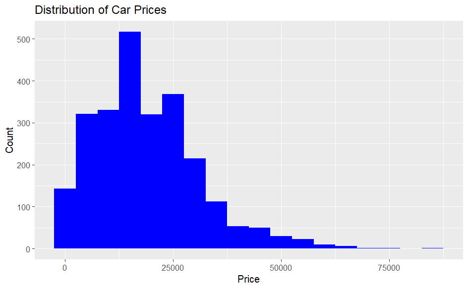

```r
# Create a histogram of price
price_distro <-  ggplot(cars_df_new, aes(x = price)) +
  geom_histogram(binwidth = 5000, fill = "blue") +
  labs(x = "Price", y = "Count", title = "Distribution of Car Prices")

price_distro
ggsave("price_distro.png", plot = price_distro , width = 6, height = 4)
```

Let’s look at prices and car age..

HYPOTHESIS: CARS THAT ARE NEWER ARE MORE EXPENSIVE THAN OLDER CARS Where the metric for measuring newer = most recent year,

12. How does the age of the car (based on the year column) relate to its price?

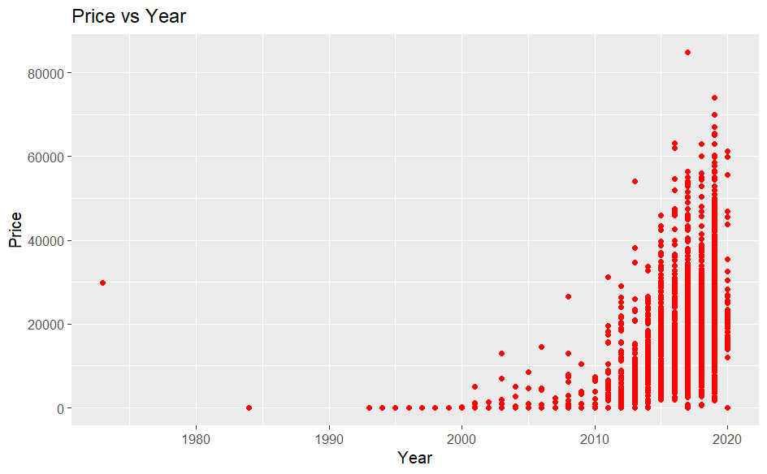

```r
#I will create a scatterplot with 'year' on the x-ais and 'price' on the y-axis to visualize the relationship
price_v_year <- ggplot(cars_df_new, aes(x = year, y = price)) +
  geom_point(color = 'red') +
  labs(x = "Year", y = "Price", title = "Price vs Year")

price_v_year

ggsave("price_v_year.png", plot = price_v_year , width = 6, height = 4)
```

OBS: From this image, we see that the prices are higher by recency. This supports the hypothesis that cars are more expensive with recency

First, There’s a visible upward trend, indicating that as the year of manufacture increases, so does the price.

Second, Newer cars, especially those manufactured after 2010, tend to cluster at higher price points

third, while the trend is upward, there is variability, suggesting that other factors besides age may also influence the price.

13.How does the mileage of the car relate to its price? HYPOTHESIS: CARS WITH LOWER MILEAGE ARE MORE EXPENSIVE THAN CARS WITH HIGHER MILEAGE test:

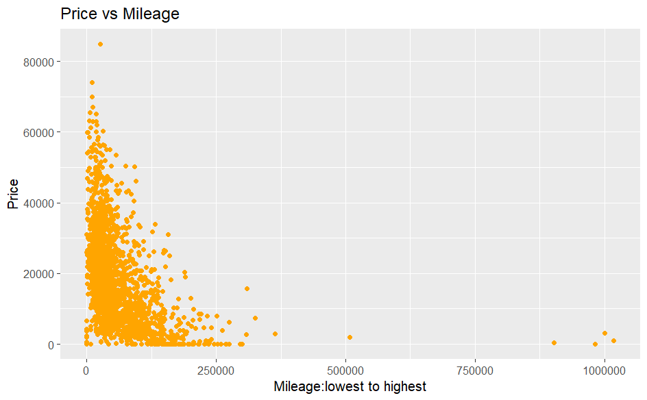

```r
#I will plot mileage by price
price_miles <- ggplot(cars_df_new, aes(x = mileage, y = price)) +
  geom_point(color = 'orange') +
  labs(x = "Mileage:lowest to highest", y = "Price", title = "Price vs Mileage")

price_miles
ggsave("price_mile.png", plot = price_miles , width = 6, height = 4)
```

Obs : From the graph we can see that the cars with low mileage are priced higher than those with high mileage

First, we see a general downward trend, suggesting that as mileage increases, the price of cars tend to decrease

Second, Cars with lower mileage are clustered at higher price points, supporting the hypothesis that they are more expensive than cars with higher mileage.

Third, The dense cluster of points at the lower end of the mileage spectrum shows a concentration of cars with lower mileage and higher prices.

Finally, I see that there is significant variation in price within the same mileage range, indicating that factors other than mileage also affect car pricing.

Does the condition of a car affect pricing? well, let’s see 14. How does the condition of the car relate to pricing?

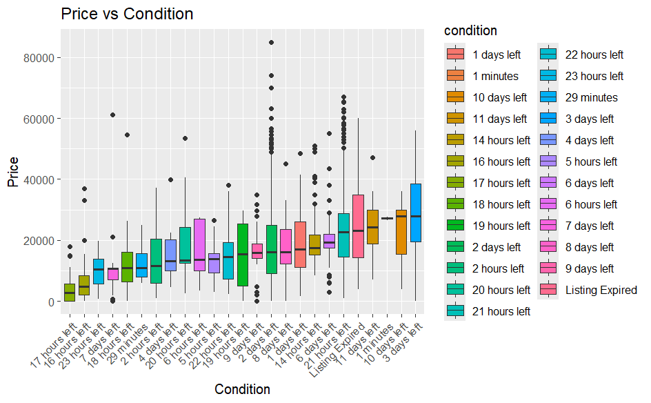

```r
#I will be using a boxplot for this
#there are a lot of conditions so let's filter
filtered_cars_df_new <- cars_df_new %>%
  group_by(condition) %>%
  filter(n() >= 10)

condition_price <- ggplot(filtered_cars_df_new, aes(x = reorder(condition, price, FUN = median), y = price, fill = condition)) +
  geom_boxplot() +
  theme(axis.text.x = element_text(angle = 45,hjust = 1)) +
  labs(x = "Condition", y = "Price", title = "Price vs Condition")

condition_price
ggsave("condition_price.png", plot = condition_price, width = 6, height = 4)
```

OBS:

first, The colors indicate the different time duration left before listings expire, which may also affect pricing.